# Week 2, Regression analysis

This week’s exercise is about regression analysis. Tasks include:

- data import and simple manipulation
- data exploration
- single and multiple predictor linear regression analysis including model diagnostics and interpretation.

Source data: http://s3.amazonaws.com/assets.datacamp.com/production/course_2218/datasets/learning2014.txt.

```r
date()
```

```
## [1] "Tue Nov 17 12:48:13 2020"
```

## Starting routines and getting to know data

```r
#Setting working path
setwd("/home/ls/R/projekteja/IODS-project/")

#Reading saved datafile as "excercise2"
exercise2_data <- read.table("./data/ex2.rData")

#Structure of data set (166 obs, 7 vars)
str(exercise2_data)
```

```
## 'data.frame':    166 obs. of  7 variables:
##  $ gender  : Factor w/ 2 levels "F","M": 1 2 1 2 2 1 2 1 2 1 ...
##  $ Age     : int  53 55 49 53 49 38 50 37 37 42 ...
##  $ Attitude: int  37 31 25 35 37 38 35 29 38 21 ...
##  $ deep    : num  3.58 2.92 3.5 3.5 3.67 ...
##  $ stra    : num  3.38 2.75 3.62 3.12 3.62 ...
##  $ surf    : num  2.58 3.17 2.25 2.25 2.83 ...
##  $ Points  : int  25 12 24 10 22 21 21 31 24 26 ...
```

```r
#First 10 observations (showing single string variable, 6 continuous variables),
head(exercise2_data,n=10)
```

```
##    gender Age Attitude     deep  stra     surf Points
## 1       F  53       37 3.583333 3.375 2.583333     25
## 2       M  55       31 2.916667 2.750 3.166667     12
## 3       F  49       25 3.500000 3.625 2.250000     24
## 4       M  53       35 3.500000 3.125 2.250000     10
## 5       M  49       37 3.666667 3.625 2.833333     22
## 6       F  38       38 4.750000 3.625 2.416667     21
## 7       M  50       35 3.833333 2.250 1.916667     21
## 8       F  37       29 3.250000 4.000 2.833333     31
## 9       M  37       38 4.333333 4.250 2.166667     24
## 10      F  42       21 4.000000 3.500 3.000000     26
```

```r
summary(exercise2_data)
```

```
##  gender       Age           Attitude          deep            stra
##  F:110   Min.   :17.00   Min.   :14.00   Min.   :1.583   Min.   :1.250
##  M: 56   1st Qu.:21.00   1st Qu.:26.00   1st Qu.:3.333   1st Qu.:2.625
##          Median :22.00   Median :32.00   Median :3.667   Median :3.188
##          Mean   :25.51   Mean   :31.43   Mean   :3.680   Mean   :3.121
##          3rd Qu.:27.00   3rd Qu.:37.00   3rd Qu.:4.083   3rd Qu.:3.625
##          Max.   :55.00   Max.   :50.00   Max.   :4.917   Max.   :5.000
##       surf           Points
##  Min.   :1.583   Min.   : 7.00
##  1st Qu.:2.417   1st Qu.:19.00
##  Median :2.833   Median :23.00
##  Mean   :2.787   Mean   :22.72
##  3rd Qu.:3.167   3rd Qu.:27.75
##  Max.   :4.333   Max.   :33.00
```

```r
#Gender proportions: females 66.3%, males 33.7%
prop.table(table(exercise2_data$gender))
```

```
##
##         F         M
## 0.6626506 0.3373494
```

So that was basic information about data set, which consist of 166 observations and single factor, six continuous variables, with 66% of subjects being female. For more information, please visit http://www.helsinki.fi/~kvehkala/JYTmooc/JYTOPKYS3-meta.txt where the original data set described.

## Visualizing pairwise distributions

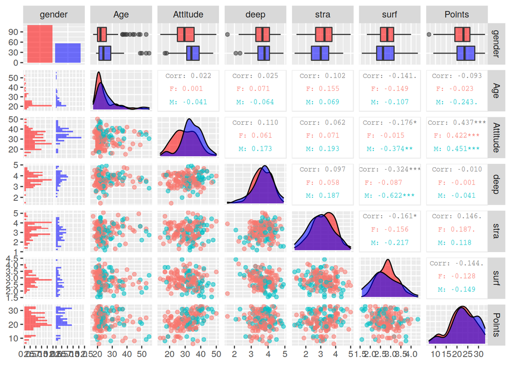

```r
#Loading additional packages and plotting bivariate distributions
library(ggplot2)
library(GGally)

ggpairs(exercise2_data, aes(col=gender, alpha=0.3),
        upper=list(continuous = wrap("cor", size=2.5)),
        lower=list(combo=wrap("facethist", bins=25))) +
  scale_fill_manual(values = c("red","blue"))
```

In graph above, red color indicates female gender, blue male. Correlation text size decreased for better fit.

Highest absolute correlation coefficient with Points are:

| Variables | Pearson R |
| --- | --- |
| Attitude * Points | 0.437 |
| stra * Points | 0.146 |
| surf * Points | -0.144 |

-> Let’s select these three as predictors. Points is the outcome.

## Multiple linear regression model #1

```r
glm1 <- lm(Points ~ Attitude + stra + surf, data=exercise2_data)
summary(glm1)
```

```
##
## Call:
## lm(formula = Points ~ Attitude + stra + surf, data = exercise2_data)
##
## Residuals:
##      Min       1Q   Median       3Q      Max
## -17.1550  -3.4346   0.5156   3.6401  10.8952
##
## Coefficients:
##             Estimate Std. Error t value Pr(>|t|)
## (Intercept) 11.01711    3.68375   2.991  0.00322 **
## Attitude     0.33952    0.05741   5.913 1.93e-08 ***
## stra         0.85313    0.54159   1.575  0.11716
## surf        -0.58607    0.80138  -0.731  0.46563
## ---
## Signif. codes:  0 '***' 0.001 '**' 0.01 '*' 0.05 '.' 0.1 ' ' 1
##
## Residual standard error: 5.296 on 162 degrees of freedom
## Multiple R-squared:  0.2074, Adjusted R-squared:  0.1927
## F-statistic: 14.13 on 3 and 162 DF,  p-value: 3.156e-08
```

Attitude is the only statistically significant predictor for Points (p<0.001).

Surf is least significant predictor: let’s remove it from the model.

## Multiple linear regression model #2

```r
glm2 <- lm(Points ~ Attitude + stra, data=exercise2_data)
summary(glm2)
```

```
##
## Call:
## lm(formula = Points ~ Attitude + stra, data = exercise2_data)
##
## Residuals:
##      Min       1Q   Median       3Q      Max
## -17.6436  -3.3113   0.5575   3.7928  10.9295
##
## Coefficients:
##             Estimate Std. Error t value Pr(>|t|)
## (Intercept)  8.97290    2.39591   3.745  0.00025 ***
## Attitude     0.34658    0.05652   6.132 6.31e-09 ***
## stra         0.91365    0.53447   1.709  0.08927 .
## ---
## Signif. codes:  0 '***' 0.001 '**' 0.01 '*' 0.05 '.' 0.1 ' ' 1
##
## Residual standard error: 5.289 on 163 degrees of freedom
## Multiple R-squared:  0.2048, Adjusted R-squared:  0.1951
## F-statistic: 20.99 on 2 and 163 DF,  p-value: 7.734e-09
```

Attitude is still the only statistically significant predictor for Points (p<0.001).

Stra is not significant, but still p<0.1. We might leave the model as it is, but out of curiosity, let’s remove Stra anyway and see what happens.

## Simple linear regression model

```r
glm3 <- lm(Points ~ Attitude, data=exercise2_data)
summary(glm3)
```

```
##
## Call:
## lm(formula = Points ~ Attitude, data = exercise2_data)
##
## Residuals:
##      Min       1Q   Median       3Q      Max
## -16.9763  -3.2119   0.4339   4.1534  10.6645
##
## Coefficients:
##             Estimate Std. Error t value Pr(>|t|)
## (Intercept) 11.63715    1.83035   6.358 1.95e-09 ***
## Attitude     0.35255    0.05674   6.214 4.12e-09 ***
## ---
## Signif. codes:  0 '***' 0.001 '**' 0.01 '*' 0.05 '.' 0.1 ' ' 1
##
## Residual standard error: 5.32 on 164 degrees of freedom
## Multiple R-squared:  0.1906, Adjusted R-squared:  0.1856
## F-statistic: 38.61 on 1 and 164 DF,  p-value: 4.119e-09
```

Model parameter estimates interpretation:

Attitude is still highly significant predictor for Points (p<0.001).

Intercept equals 11.6. This is the value of Points where Attitude=0, based on model formula.

Slope parameter of Attitude equals to 0.352, i.e. single unit increase in Attitude reflects as 0.352 increase to Points.

Coefficents of determination: unadjusted 19.1%, adjusted 18.6%. Both are a bit lower than in previous model. But let’s leave it that way.

## Diagnostic plots for model #3

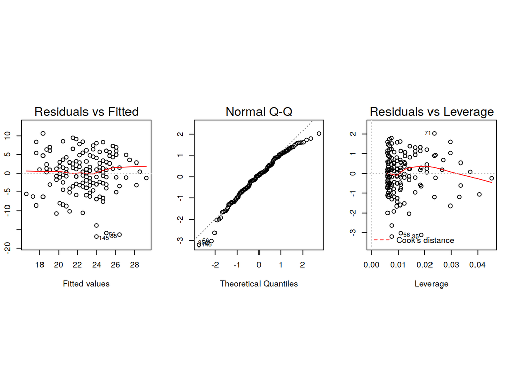

```r
#Drawing diagnostic plots. Choosing the plots 1, 2 and 5. Full list of plot options:
#1. Residual vs fitted
#2. Normal QQ plot
#3. Scale-location
#4. Cooks distance
#5. Residuals vs. Leverage
#6. Cooks distances vs Leverage

#Defining plot matrix of 1x3. Pin defines 1:1 aspect ratio for each sub plot.
par(mfrow = c(1,3), pin=c(1.75,1.75))
plot(glm3, which=c(1,2,5))
```

Normal Quantile-Quantile plot: There is slight deviation from the diagonal at the ends. However, this is still not yet alarming at all.

**Conclusion: model seems to be adequate, assumptions are met, based on visual examination. Attitude predicts value of Points.**